# Exam 1

## Exam 1

#### Question

1. In the following figure the distributions of a variable given by two samples (A and B) are represented by parallel boxplots. Which of the following statements are correct? *(Comment: The statements are either about correct or clearly wrong.)*

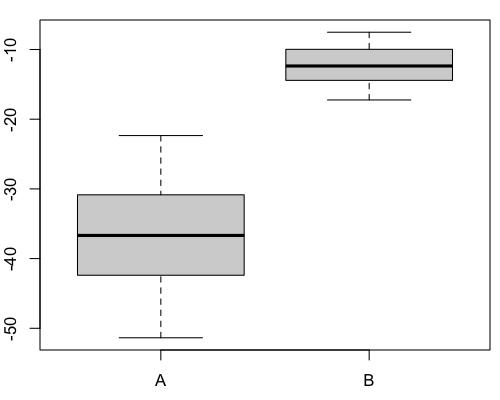

   1. The location of both distributions is about the same.
   2. Both distributions contain no outliers.
   3. The spread in sample A is clearly bigger than in B.
   4. The skewness of both samples is similar.
   5. Distribution A is left-skewed.

#### Solution

   1. False. Distribution B has on average higher values than distribution A.
   2. True. Both distributions have no observations which deviate more than 1.5 times the interquartile range from the box.
   3. True. The interquartile range in sample A is clearly bigger than in B.
   4. True. The skewness of both distributions is similar, both are about symmetric.
   5. False. Distribution A is about symmetric.

#### Question

2. The waiting time (in minutes) at the cashier of two supermarket chains with different cashier systems is compared. The following statistical test was performed:

   ```
       Two Sample t-test

   data:  Waiting by Supermarket
   t = -2.9847, df = 117, p-value = 0.003456
   alternative hypothesis: true difference in means between group Sparag and group Consumo is not equal to 0
   95 percent confidence interval:
    -2.7480469 -0.5558352
   sample estimates:
    mean in group Sparag mean in group Consumo
                4.103493              5.755434
   ```

   Which of the following statements are correct? (Significance level 5%)
   1. The absolute value of the test statistic is larger than 1.96.
   2. A one-sided alternative was tested.
   3. The p-value is larger than 0.05.
   4. The test shows that the waiting time is longer at Sparag than at Consumo.
   5. The test shows that the waiting time is shorter at Sparag than at Consumo.

#### Solution

   1. True. The absolute value of the test statistic is equal to 2.985.
   2. False. The test aims at showing that the difference of means is unequal to 0.
   3. False. The p-value is equal to 0.00346.
   4. False.
   5. True. The test result is significant ($p < 0.05$) and hence the alternative is shown, that the difference of means are unequal to 0.

#### Question

3. A survey with 50 persons was conducted to analyze the design of an advertising campaign. Each respondent was asked to evaluate the overall impression of the advertisement on an eleven-point scale from 0 (bad) to 10 (good). The evaluations are summarized separately with respect to type of occupation of the respondents in the following figure.

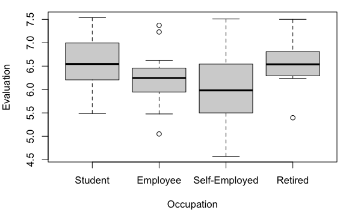

   To analyze the influence of occupation on the evaluation of the advertisement an analysis of variance was performed:

   ```
     Res.Df    RSS Df Sum of Sq    F   Pr(>F)
   1     49 23.350
   2     46 20.315  3     3.035 2.29 0.090773
   ```

   Which of the following statements are correct?
   1. The fraction of explained variance is smaller than $14$%.
   2. A one-sided alternative was tested for the mean values.
   3. The test statistic is larger than $19.9$.
   4. The fraction of explained variance is larger than $55$%.
   5. It can be shown that the evaluation of the respondents depends on their occupation. (Significance level $5$%)

#### Solution

   In order to be able to answer the questions the fraction of explained variance has to be determined. The residual sum of squares when using only a single overall mean value ($\mathit{RSS}_0$) as well as the residual sum of squares when allowing different mean values given occupation ($\mathit{RSS}_1$) are required. Both are given in the RSS column of the ANOVA table. The fraction of explained variance is given by $1 - \mathit{RSS}_1/\mathit{RSS}_0 = 1 - 20.315/23.35 = 0.13$.

   The statements above can now be evaluated as right or wrong.
   1. True. The fraction of explained variance is $0.130$ and hence smaller than 0.14.
   2. False. An ANOVA always tests the null hypothesis, that all mean values are equal against the alternative hypothesis that they are different.
   3. False. The test statistic is $F = 2.290$ and hence *not* larger than $19.9$.
   4. False. The fraction of explained variance is $0.130$ and hence *not* larger than 0.55.
   5. False. The $p$ value is $0.0908$ and hence_not_ significant. It can *not* be shown that the evaluations differ with respect to the occupation of the respondents.

#### Question

4. The following figure shows a scatterplot. Which of the following statements are correct?

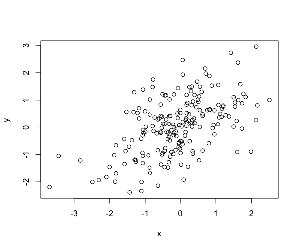

   1. For $X = 0.8$, $Y$ can be expected to be about $-1.6$.
   2. The standard deviation of $X$ is at least $6$.
   3. The mean of $X$ is at most $5$.
   4. The slope of the regression line is about $1$.
   5. The absolute value of the correlation coefficient is at most $0.8$.

#### Solution

   1. False. The regression line at $X=0.8$ implies a value of about $Y = 0.4$.
   2. False. The standard deviation of $X$ is about equal to $1$ and is therefore smaller than $6$.
   3. True. The mean of $X$ is about equal to $0$ and hence is smaller than $5$.
   4. False. The slope of the regression line is given by $r \cdot s_y/s_x$ and hence not about equal to $1$.
   5. True. Only a slightly positive association between the variables is observable in the scatterplot. This implies a correlation coefficient with an absolute value smaller than $0.8$.

#### Question

5. In a small city the satisfaction with the local public transportation is evaluated. One question of interest is whether inhabitants of the city are more satisfied with public transportation compared to those living in the suburbs.

   A survey with 250 respondents gave the following contingency table:

   ```
              Location
   Evaluation  City Suburbs
     Very good   29      25
     Good        37      31
     Bad         27      56
     Very bad     7      38
   ```

   The following table of percentages was constructed:

   ```
              Location
   Evaluation  City    Suburbs
     Very good    11.6    10.0
     Good         14.8    12.4
     Bad          10.8    22.4
     Very bad      2.8    15.2
   ```

   Which of the following statements are correct?
   1. The percentage table provides total percentages.
   2. The percentage table can be easily constructed from the original contingency table: percentages are calculated for each row.
   3. The value in row 3 and column 1 in the percentage table indicates: 10.8 percent of the respondents lived in the city and evaluated the public transportation as bad.
   4. The value in row 1 and column 2 in the percentage table indicates: 10 percent of those living in the suburbs evaluated the public transportation as very good.
   5. The percentage table provides the location distribution for each level of satisfaction.

#### Solution

   In the percentage table, the total sums are about 100 (except for possible rounding errors). Hence, the table provides total percentages, i.e., the relative frequencies for each combination of location type and satisfaction level.
   1. True. The total sums are about equal to 100 (except for possible rounding errors).
   2. False. This calculation yields row percentages. But the table provides total percentages.
   3. True. This is the correct interpretation for total percentages.
   4. False. This is an interpretation for column percentages, but the table provides total percentages.
   5. False. The row sums are not equal to 100.